# In-Season ONLY

viwa

2024-08-22

### 2. In-Season Survey Analysis

#### Where are visitors from?

*Understanding visitor origins by their manually collected zip codes.*

Rationale: non-5 digit zip codes were omitted, as it is difficult to determine the typing error committed to lead to an abnormal zip code. Additionally, collapsed all zip codes collected with count == 1 into an “Other” category in order to better visualize most common visitor homes.

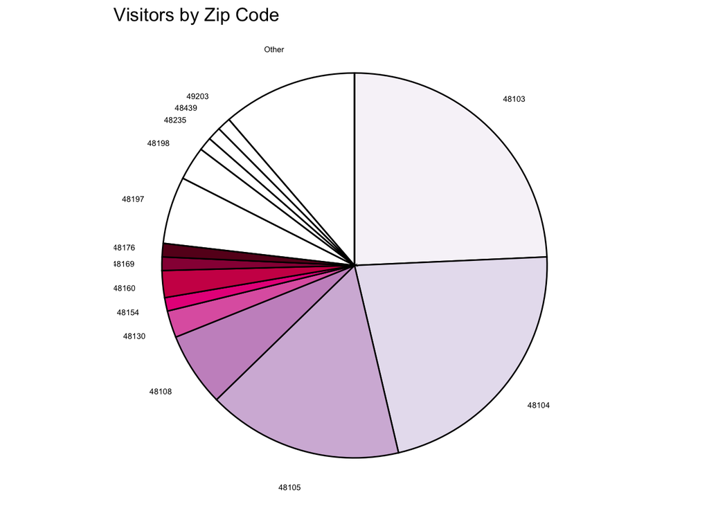

*Secondary data visualization method, mapping visitor hometowns.*

Rationale: Pie charts fail to visually assess distance and neighborhood from which participants traveled. Mapping is used to determine density and distance. First, use geocode() to add latitude and longitudes to the dataframe based on their zip code.

[interactive chart not shown]

*Visitors by home county.*

Although county data was not explicitly collected, we can extrapolate from zipcode data by using the zipcodeR package. This allows us to see zip code characteristics like population size, area in square miles, among other metadata.

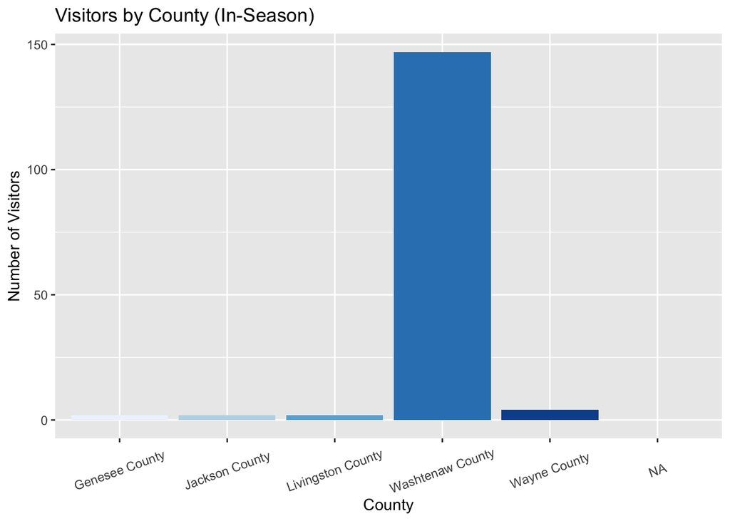

#### What ages are visitors?

*Bar graph of number of visitors by their selected age group.*

Visitor ages are re-ordered in chronological form and labels are shortened to promote figure readability. A significantly high number of visitors were between the ages of 18-24. This may be due to a variety of reasons, including: (1) survey canvassers were in this approximate range, (2) younger adults have higher technological proficiency, among others.

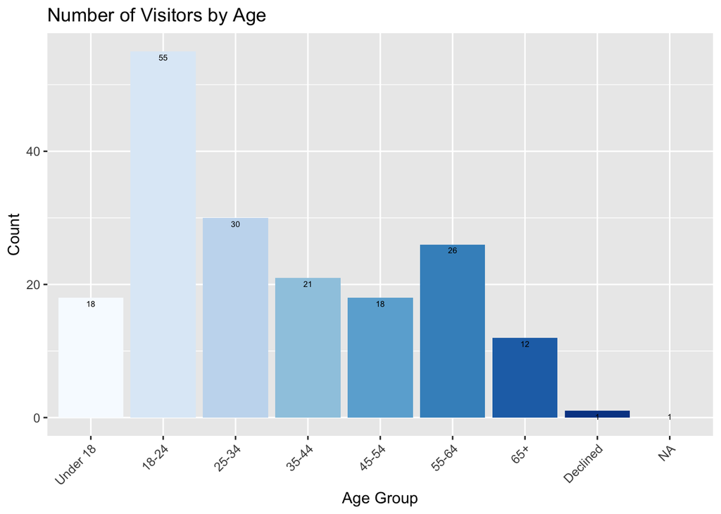

#### Visitor gender demographics

*Bar graph of number of visitors by their self-identified gender.*

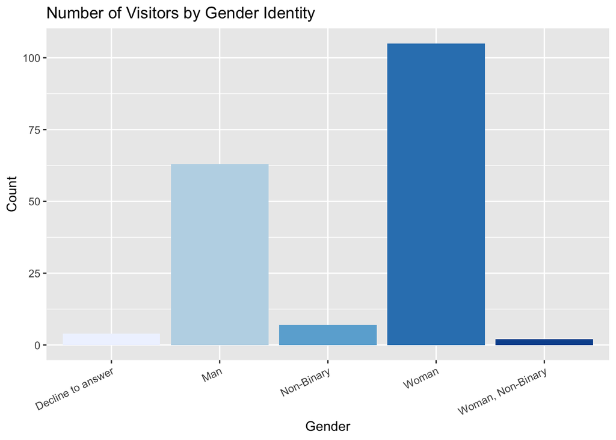

#### Ethnic demographics

*Ethnic demographics data was collected via a “Select all that apply” question, so multiple unique combinations of background were identified.*

| Race/Ethnicity | Number of Respondents |
| --- | --- |
| White | 121 |
| Asian | 17 |
| Black or African American | 10 |
| Hispanic, Latino or Spanish origin | 8 |
| American Indian or Alaska Native | 3 |
| Mixed heritage | 3 |
| American Indian or Alaska Native, White | 2 |
| Asian, Hispanic, Latino or Spanish origin | 2 |
| Decline to answer | 2 |
| Middle Eastern and North African (MENA) | 2 |
| White, Middle Eastern and North African (MENA) | 2 |
| American Indian or Alaska Native, Hispanic, Latino or Spanish origin, White | 1 |
| Asian, White | 1 |
| Asian, White, Mixed heritage | 1 |
| Black or African American, White | 1 |
| Black or African American, White, Mixed heritage | 1 |
| Hispanic, Latino or Spanish origin, White | 1 |
| Middle Eastern and North African (MENA), Mixed heritage | 1 |

*Create a new table that collapses multiple race and ethnicity selections into a single “Mixed heritage” category.*

Rationale: “Mixed Heritage” could be used to describe any combination of one or more racial/ethnic backgrounds, but those who also selected the combination of their backgrounds leads to many distinct demographic categorizations. A hierarchical approach that both factors a general category, as well as more common combinations, helps make the number of groups more meaningful.

| Race/Ethnicity | Count |
| --- | --- |
| White | 121 |
| Asian | 17 |
| Mixed heritage | 16 |
| Black or African American | 10 |
| Hispanic, Latino or Spanish origin | 8 |
| American Indian or Alaska Native | 3 |
| Decline to answer | 2 |
| Middle Eastern and North African (MENA) | 2 |

#### Visitor programming satisfaction

*Break out favorite offerings tonight by day.*

Programming questions were asked slightly differently between the in-season and post-season survey versions, as in-season questionnaires were administered in-time with programming.

*Number of visitors indicating one of the multiple selections available per day over the in-season respondent period.*

Please note: data was not collected on 6/17 and 6/24 because the festival was dark on these days.

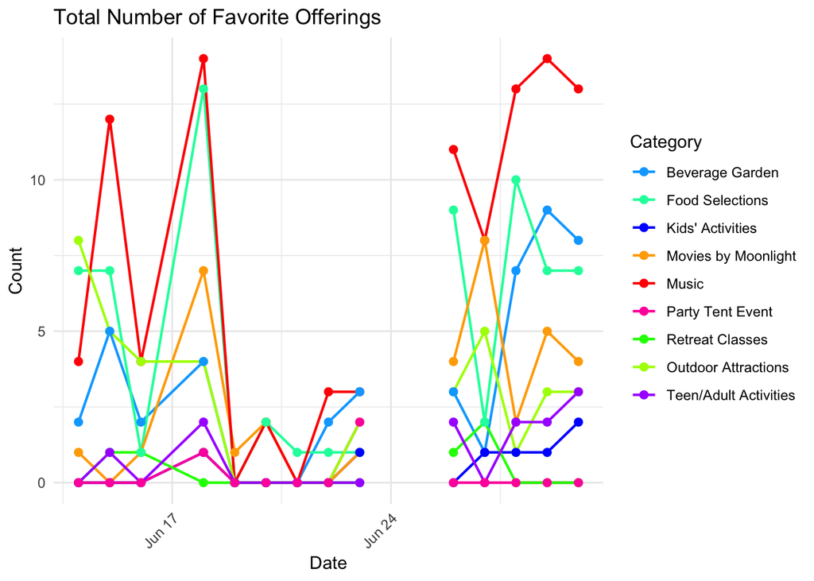

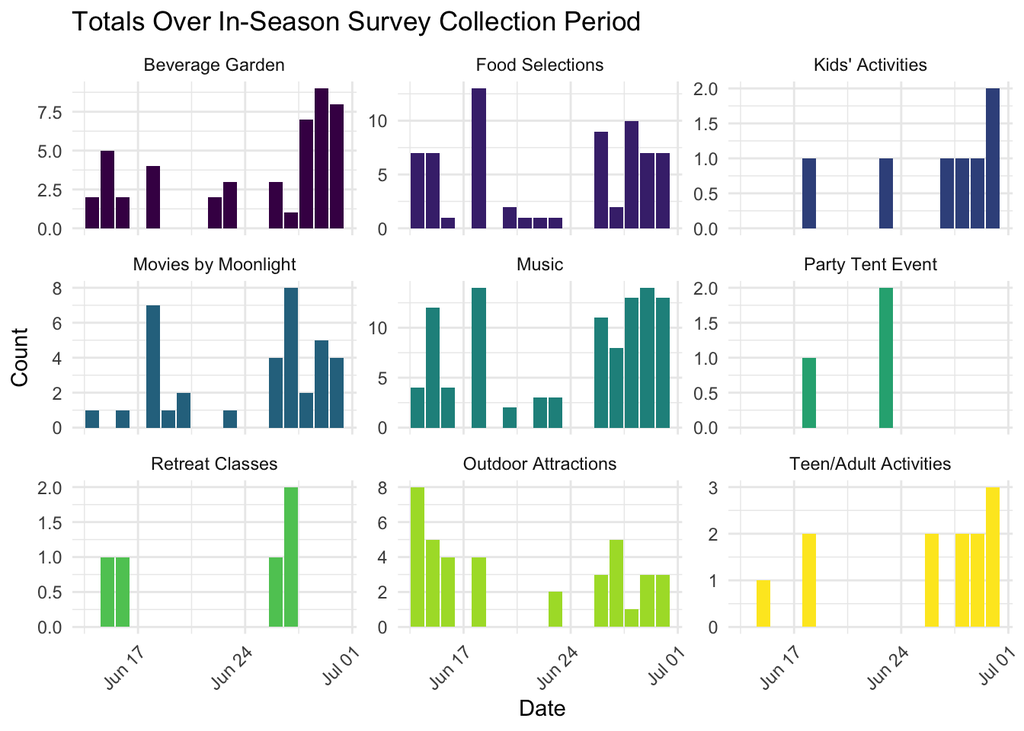

*Other respondent-identified “favorite offerings” during the in-season survey collection period.*

| Date | Other Favorite Offerings |
| --- | --- |
| 2024-06-25 | trivia! |
| 2024-06-25 | CHELAS |
| 2024-06-29 | This survey |
| 2024-06-29 | Great overall vibe |

#### Family Demographics

*To filter, we choose the optional string column “On a scale of 1-10, how satisfied are you with family offerings (KidZone, Kids Rock) at Top of the Park?” to determine whether respondents represent a family.*

| Age Group | Count |
| --- | --- |
| Under 18 years | 13 |
| 18 to 24 years | 35 |
| 25 to 34 years | 17 |
| 35 to 44 years | 15 |
| 45 to 54 years | 12 |
| 55 to 64 years | 13 |
| 65 or older | 5 |
| Decline to answer | 1 |
| NA | 1 |

*Most people seemed to have answered the optional “On a scale of 1-10, how satisfied are you with family offerings (KidZone, Kids Rock) at Top of the Park?”, so it may also be relevant to highlight the people who mentioned Kids’ Activities as one of their top 3 offerings.*

| Date | Age | Top 3 Favorite Offerings | Kids’ Activities Satisfaction | Anything else to share? | Making it easier to participate | How did you hear? |
| --- | --- | --- | --- | --- | --- | --- |
| 2024-06-18 | Under 18 years | Music at Top of the Park, Movies by Moonlight, Kids’ Activities (under age 11) in KidZone | 7 | Nope :) | Location | From Naya Shalom Loftus |
| 2024-06-23 | 35 to 44 years | Special Outdoor Attractions (circus, street performances), The Grove Beverage Garden, Kids’ Activities (under age 11) in KidZone | 10 | N/a | N/a | Been attending for years |
| 2024-06-25 | 65 or older | Music at Top of the Park, Special Outdoor Attractions (circus, street performances), Kids’ Activities (under age 11) in KidZone | 5 | No | Nothing | Friend |
| 2024-06-25 | 45 to 54 years | Music at Top of the Park, Special Outdoor Attractions (circus, street performances), Kids’ Activities (under age 11) in KidZone | 10 | Stop using diesel generators. Gross. It’s 2024! | Don’t have mandatory fields for voluntary surveys | Live here |
| 2024-06-25 | 18 to 24 years | Retreat Classes on Power Center lawn (yoga, tai chi, etc.), Kids’ Activities (under age 11) in KidZone | 5 | N/A | Better Mexican food. | The university of Michigan |
| 2024-06-25 | 35 to 44 years | Music at Top of the Park, Retreat Classes on Power Center lawn (yoga, tai chi, etc.), Kids’ Activities (under age 11) in KidZone | 8 | Wish there were more food options, vendors, and seating. I wish it provided opportunities for local/independent artists (but not Art fair prices-too expensive for most). | Getting the schedule in advance to carve out time to go | Unsure |
| 2024-06-27 | 25 to 34 years | Music at Top of the Park, Special Outdoor Attractions (circus, street performances), Kids’ Activities (under age 11) in KidZone | 7 | Love it! | I don’t really even know about others beyond TOP | Branding |
| 2024-06-28 | 55 to 64 years | Music at Top of the Park, Food Selections, Kids’ Activities (under age 11) in KidZone | 10 | Love David Zinn | Will attend | Onlune |
| 2024-06-29 | 45 to 54 years | Special Outdoor Attractions (circus, street performances), The Grove Beverage Garden, Kids’ Activities (under age 11) in KidZone | 10 | We love these weeks! It’s part of what makes A2 magical!! THANK YOU!! | Earlier events | Family |
| 2024-06-30 | 18 to 24 years | Kids’ Activities (under age 11) in KidZone, Teen and Adult Activities (age 11+) in the Annex | 10 | N/a | Free parking and more games for the kids | Saw it |
| 2024-06-30 | 45 to 54 years | Special Outdoor Attractions (circus, street performances), The Grove Beverage Garden, Kids’ Activities (under age 11) in KidZone | 9 | Expand fenced in area for adult beverages so adults can have a drink while on the lawn or in front of the stage | N/a | Returning attendees |